# Hypothesentest

Sanja Perovic, Julia Zerrweck

8/13/2020

```r
library(readr)
library(tidyverse)
mafo <- read_csv("responses.csv")
mafo <- drop_na(mafo)
```

```r
glimpse (mafo)
```

```
## Rows: 674
## Columns: 150
## $ Music                            <dbl> 5, 4, 5, 5, 5, 5, 5, 5, 5, 5, 5, 5, …
## $ `Slow songs or fast songs`       <dbl> 3, 4, 5, 3, 3, 5, 3, 3, 3, 3, 3, 3, …
## $ Dance                            <dbl> 2, 2, 2, 4, 2, 5, 3, 2, 3, 1, 1, 5, …
## $ Folk                             <dbl> 1, 1, 2, 3, 3, 3, 2, 5, 2, 1, 2, 3, …
## $ Country                          <dbl> 2, 1, 3, 2, 2, 1, 1, 2, 1, 1, 1, 2, …
## $ `Classical music`                <dbl> 2, 1, 4, 4, 3, 2, 2, 2, 2, 4, 4, 1, …
## $ Musical                          <dbl> 1, 2, 5, 3, 3, 2, 2, 5, 3, 1, 3, 5, …
## $ Pop                              <dbl> 5, 3, 3, 5, 2, 5, 4, 3, 4, 2, 3, 5, …
## $ Rock                             <dbl> 5, 5, 5, 3, 5, 3, 5, 5, 3, 5, 5, 2, …
## $ `Metal or Hardrock`              <dbl> 1, 4, 3, 1, 5, 1, 1, 2, 2, 1, 4, 1, …
## $ Punk                             <dbl> 1, 4, 4, 2, 3, 1, 2, 3, 1, 1, 2, 1, …
## $ `Hiphop, Rap`                    <dbl> 1, 1, 1, 5, 4, 3, 3, 2, 3, 1, 3, 2, …
## $ `Reggae, Ska`                    <dbl> 1, 3, 4, 3, 3, 1, 2, 4, 2, 1, 1, 1, …
```

[output cut: 137 more lines]

```r
mafo <- drop_na(mafo)
```

# 2 Deskriptive Statistik

## Nominal 1

### Modus

```r
table(mafo$Gender)
```

```
##
## female   male
##    402    272
```

## Metrisch 1

### Mittelwert

```r
mean (mafo$Age)
```

```
## [1] 20.35312
```

### Modus

```r
table(mafo$Age)
```

```
##
##  15  16  17  18  19  20  21  22  23  24  25  26  27  28  29  30
##   6  15  42  85 147 132  84  50  34  19  20  10   8  11   5   6
```

### Median

```r
median(mafo$Age)
```

```
## [1] 20
```

### Quartilsabstände

```r
IQR(mafo$Age)
```

```
## [1] 2
```

### Standardabweichung

```r
sd(mafo$Age)
```

```
## [1] 2.732763
```

## Metrisch 2

### Mittelwert

```r
mean(mafo$Weight)
```

```
## [1] 66.11721
```

### Modus

```r
table(mafo$Weight)
```

```
##
##  41  42  43  44  45  46  47  48  49  50  51  52  53  54  55  56  57  58  59  60
##   1   1   2   3   5   5   5  12  10  30  11  15  19  18  34  15  25  24   6  53
##  61  62  63  64  65  66  67  68  69  70  71  72  73  74  75  76  77  78  79  80
##   5  18  21  14  30   5  10  19   5  34   6   9   7  10  31  12  10   8   4  29
##  81  82  83  84  85  86  87  88  89  90  92  93  95  96  97  98  99 100 103 105
##   5   7  11   4  12   3   3   6   3  15   3   2   3   1   1   1   1   2   1   1
## 110 111 113 120 125 150
##   1   1   1   3   1   1
```

### Median

```r
median(mafo$Weight)
```

```
## [1] 63
```

### Quartilsabstände

```r
IQR(mafo$Weight)
```

```
## [1] 20
```

### Standardabweichung

```r
sd (mafo$Weight)
```

```
## [1] 13.90029
```

# Ordinal 1

### Mittelwert

```r
mean(mafo$Loneliness)
```

```
## [1] 2.890208
```

### Modus

```r
table(mafo$Loneliness)
```

```
##
##   1   2   3   4   5
##  79 177 228 119  71
```

### Median

```r
median(mafo$Loneliness)
```

```
## [1] 3
```

### Quartilsabstände

```r
IQR(mafo$Loneliness)
```

```
## [1] 2
```

### Standardabweichung

```r
sd (mafo$Loneliness)
```

```
## [1] 1.148599
```

# Ordinal 2

### Mittelwert

```r
mean(mafo$God)
```

```
## [1] 3.228487
```

### Modus

```r
table(mafo$God)
```

```
##
##   1   2   3   4   5
## 134  86 141 118 195
```

### Median

```r
median(mafo$God)
```

```
## [1] 3
```

### Quartilsabstände

```r
IQR(mafo$God)
```

```
## [1] 3
```

### Standardabweichung

```r
sd (mafo$God)
```

```
## [1] 1.485348
```

# 3 Hypothesentests

## a

```r
t.test(mafo$`Friends versus money` ~ Gender, data = mafo)
```

```
##
##  Welch Two Sample t-test
##
## data:  mafo$`Friends versus money` by Gender
## t = 3.006, df = 532.87, p-value = 0.002772
## alternative hypothesis: true difference in means is not equal to 0
## 95 percent confidence interval:
##  0.09234887 0.44068449
## sample estimates:
## mean in group female   mean in group male
##             3.873134             3.606618
```

p-Wert unter 0.05: Wert ist also signifikant und kann nicht verworfen werden. das heißt, es gibt einen Unterschied zwischen den Geschlechtern bei der Präferenz.

### 1

H1: Zwischen den Geschlechtern gibt es einen Unterschied in deren Präferenz für Freunde vs. Geld. H0: Zwischen den Geschlechtern gibt es keinen Unterschied in deren Präferenz für Freunde vs. Geld.

### 2

Beantworten Sie jeweils die folgenden Fragen (Hinweis: nutzen Sie ein Histogramm für die Prüfung der Verteilung): - Skalenniveau abhängige Variable Ordinalskala

- Skalenniveau unabhängige Variable (Gruppenvariable) Nominalskala
- Unabhängigkeit der Stichproben (ja/nein) Ja, da die beiden Variablen sich nicht gegenseitig beeinflussen.
- Stufen der unabhängigen Variable  
  Männlich, Weiblich
- Geeigneter Hypothesentest t-Test

### 3

```r
t.test(mafo$`Friends versus money` ~ Gender, data = mafo)
```

```
##
##  Welch Two Sample t-test
##
## data:  mafo$`Friends versus money` by Gender
## t = 3.006, df = 532.87, p-value = 0.002772
## alternative hypothesis: true difference in means is not equal to 0
## 95 percent confidence interval:
##  0.09234887 0.44068449
## sample estimates:
## mean in group female   mean in group male
##             3.873134             3.606618
```

#### - Verteilung der abhängigen Variable

```r
sum(mafo$`Friends versus money` == 1)
```

```
## [1] 28
```

```r
sum(mafo$`Friends versus money` == 2)
```

```
## [1] 52
```

```r
sum(mafo$`Friends versus money` == 3)
```

```
## [1] 188
```

```r
sum(mafo$`Friends versus money` == 4)
```

```
## [1] 188
```

```r
sum(mafo$`Friends versus money` == 5)
```

```
## [1] 218
```

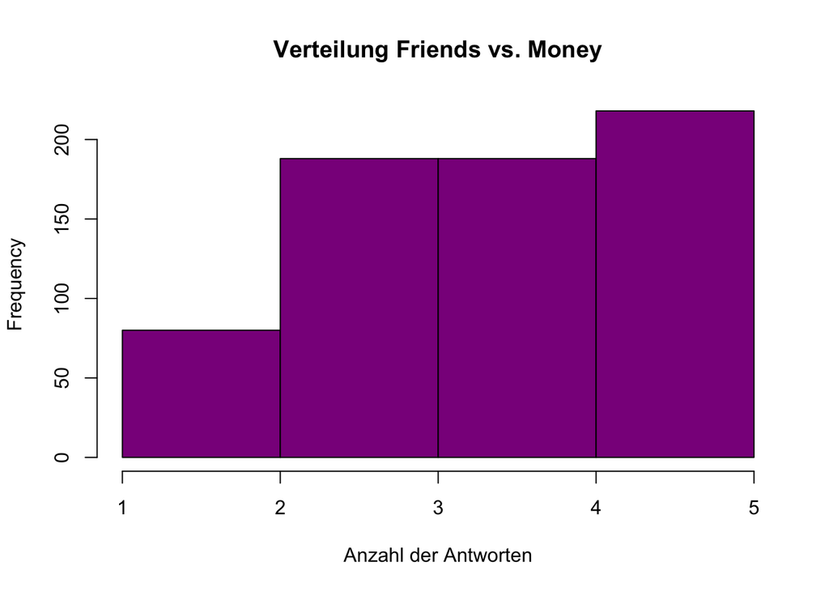

```r
friendsvsmoney <- mafo$`Friends versus money`
hist(friendsvsmoney,
     main="Verteilung Friends vs. Money",
     xlab="Anzahl der Antworten",
     xlim=c(1,5),
     breaks = c(5),
     col="darkmagenta")
```

#### 1. Hypothese

70% der Teilnehmer sind über 170 cm groß.

```r
sum(mafo$Height >= 170)
```

```
## [1] 436
```

```r
binom1 <- binom.test(436, 674, 0.7)

binom1
```

```
##
##  Exact binomial test
##
## data:  436 and 674
## number of successes = 436, number of trials = 674, p-value = 0.003226
## alternative hypothesis: true probability of success is not equal to 0.7
## 95 percent confidence interval:
##  0.6094787 0.6829971
## sample estimates:
## probability of success
##              0.6468843
```

ist signifikant

#### 2. Hypothese

90% der Teilnehmer wiegen über 50kg.

```r
sum(mafo$Weight >= 50)
```

```
## [1] 630
```

```r
binom1 <- binom.test(630, 674, 0.9)

binom1
```

```
##
##  Exact binomial test
##
## data:  630 and 674
## number of successes = 630, number of trials = 674, p-value = 0.001997
## alternative hypothesis: true probability of success is not equal to 0.9
## 95 percent confidence interval:
##  0.913350 0.952169
## sample estimates:
## probability of success
##              0.9347181
```

ist signifikant

#### 1. Hypothese

Menschen, die mehr Geschwister haben fühlen sich weniger einsam.

```r
chisq.test(mafo$`Number of siblings`, mafo$Loneliness)
```

```
##
##  Pearson's Chi-squared test
##
## data:  mafo$`Number of siblings` and mafo$Loneliness
## X-squared = 26.853, df = 28, p-value = 0.5263
```

Ist nicht signifikant, da der p-Wert über 0.05 liegt: wird verworfen.

#### 2. Hypothese

Menschen die aktiv Sport betreiben geben mehr Geld für gesundes Essen aus.

```r
chisq.test(mafo$`Active sport`, mafo$`Spending on healthy eating`)
```

```
##
##  Pearson's Chi-squared test
##
## data:  mafo$`Active sport` and mafo$`Spending on healthy eating`
## X-squared = 28.813, df = 16, p-value = 0.02523
```

Ist signifikant und wird nicht verworfen.